# Homework4

Xuan Yu

10/05/2018

## Maternal Smoking and Premature Birth

Read in the data.

```r
library("pROC")
library("arm")
maternal_data <- read.csv("/Users/xuanyu/Desktop/MIDS courses/data modeling/HW/HW4/smoking.csv")
maternal_data$premature <- rep(0, nrow(maternal_data))
maternal_data$premature[maternal_data$gestation < 270] <- 1

maternal_data$mrace_new <- maternal_data$mrace
maternal_data$mrace_new[maternal_data$mrace >= 0 & maternal_data$mrace <= 5] <- 5

maternal_data$who_smoke <- maternal_data$smoke
maternal_data$who_smoke[maternal_data$smoke != 0] <- 1

dim(maternal_data)
```

```
## [1] 869  15
```

```r
summary(maternal_data)
```

```
##        id            date        gestation         bwt.oz
##  Min.   :  15   Min.   :1350   Min.   :148.0   Min.   : 55.0
##  1st Qu.:5477   1st Qu.:1444   1st Qu.:272.0   1st Qu.:108.0
##  Median :6734   Median :1540   Median :279.0   Median :119.0
##  Mean   :6032   Mean   :1536   Mean   :278.5   Mean   :118.4
##  3rd Qu.:7587   3rd Qu.:1627   3rd Qu.:286.0   3rd Qu.:129.0
##  Max.   :9263   Max.   :1714   Max.   :338.0   Max.   :174.0
##      parity           mrace            mage            med
##  Min.   : 0.000   Min.   :0.000   Min.   :15.00   Min.   :0.000
##  1st Qu.: 1.000   1st Qu.:0.000   1st Qu.:23.00   1st Qu.:2.000
##  Median : 2.000   Median :2.000   Median :26.00   Median :2.000
##  Mean   : 1.953   Mean   :2.995   Mean   :27.29   Mean   :2.932
##  3rd Qu.: 3.000   3rd Qu.:7.000   3rd Qu.:31.00   3rd Qu.:4.000
##  Max.   :11.000   Max.   :9.000   Max.   :45.00   Max.   :7.000
##       mht           mpregwt           inc            smoke
##  Min.   :53.00   Min.   : 87.0   Min.   :0.000   Min.   :0.0000
##  1st Qu.:62.00   1st Qu.:113.0   1st Qu.:2.000   1st Qu.:0.0000
##  Median :64.00   Median :125.0   Median :3.000   Median :0.0000
##  Mean   :64.07   Mean   :128.5   Mean   :3.681   Mean   :0.4638
##  3rd Qu.:66.00   3rd Qu.:140.0   3rd Qu.:5.000   3rd Qu.:1.0000
##  Max.   :72.00   Max.   :220.0   Max.   :9.000   Max.   :1.0000
##    premature        mrace_new       who_smoke
##  Min.   :0.0000   Min.   :5.000   Min.   :0.0000
##  1st Qu.:0.0000   1st Qu.:5.000   1st Qu.:0.0000
##  Median :0.0000   Median :5.000   Median :0.0000
##  Mean   :0.1887   Mean   :5.604   Mean   :0.4638
##  3rd Qu.:0.0000   3rd Qu.:7.000   3rd Qu.:1.0000
##  Max.   :1.0000   Max.   :9.000   Max.   :1.0000
```

Some exploratory data analysis:

There are very few observation in education level 7 so we don’t worried about its different mean value with other level

We may care more about smoke variable and race variable:

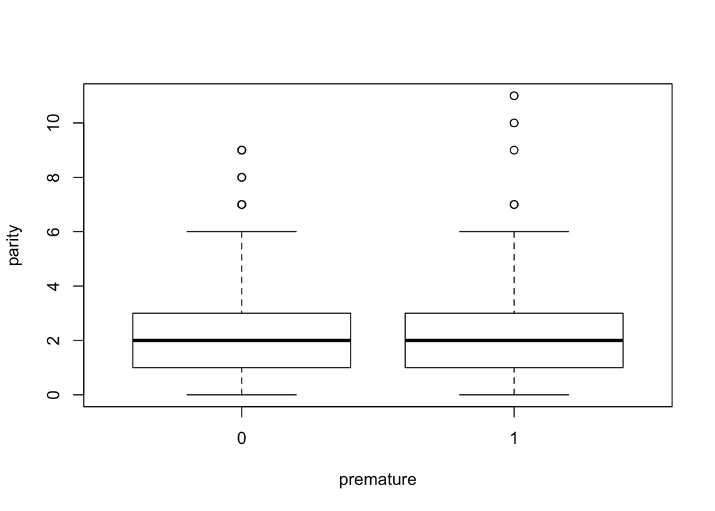

```r
boxplot(parity~premature, data = maternal_data, xlab = "premature", ylab = "parity")
```

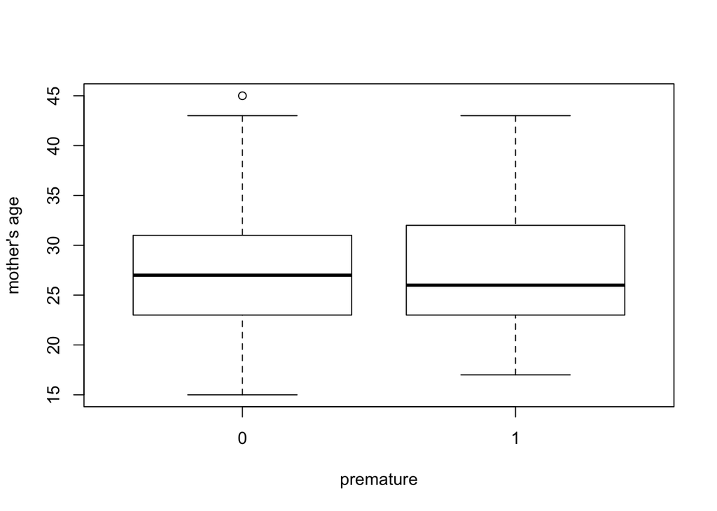

```r
boxplot(mage~premature, data = maternal_data, xlab = "premature", ylab = "mother's age")
```

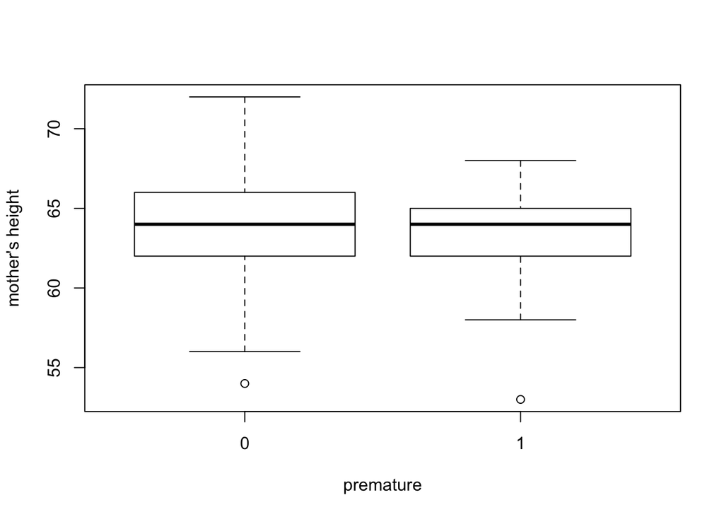

```r
boxplot(mht~premature, data = maternal_data, xlab = "premature", ylab = "mother's height")
```

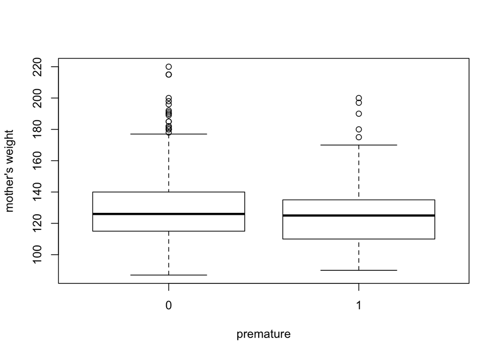

```r
boxplot(mpregwt~premature, data = maternal_data, xlab = "premature", ylab = "mother's weight")
```

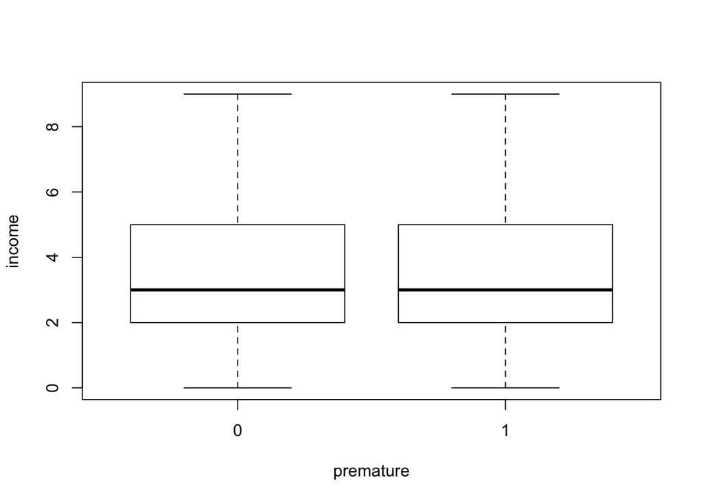

```r
boxplot(inc~premature, data = maternal_data, xlab = "premature", ylab = "income")
```

```r
tapply(maternal_data$premature, maternal_data$who_smoke, mean)
```

```
##         0         1
## 0.1652361 0.2158809
```

```r
tapply(maternal_data$premature, maternal_data$mrace_new, mean)
```

```
##          5          6          7          8          9
## 0.16134185 0.24000000 0.26627219 0.32352941 0.06666667
```

```r
tapply(maternal_data$premature, maternal_data$med, mean)
```

```
##         0         1         2         3         4         5         7
## 0.4000000 0.2769231 0.1900312 0.2340426 0.1182266 0.1698113 0.7500000
```

Now we are looking at binnedplots of continuous predictors versus premature birth: We’ll ignore the SD lines in these plots – they are only relevant when plotting binned residuals versus the predicted probabilities:

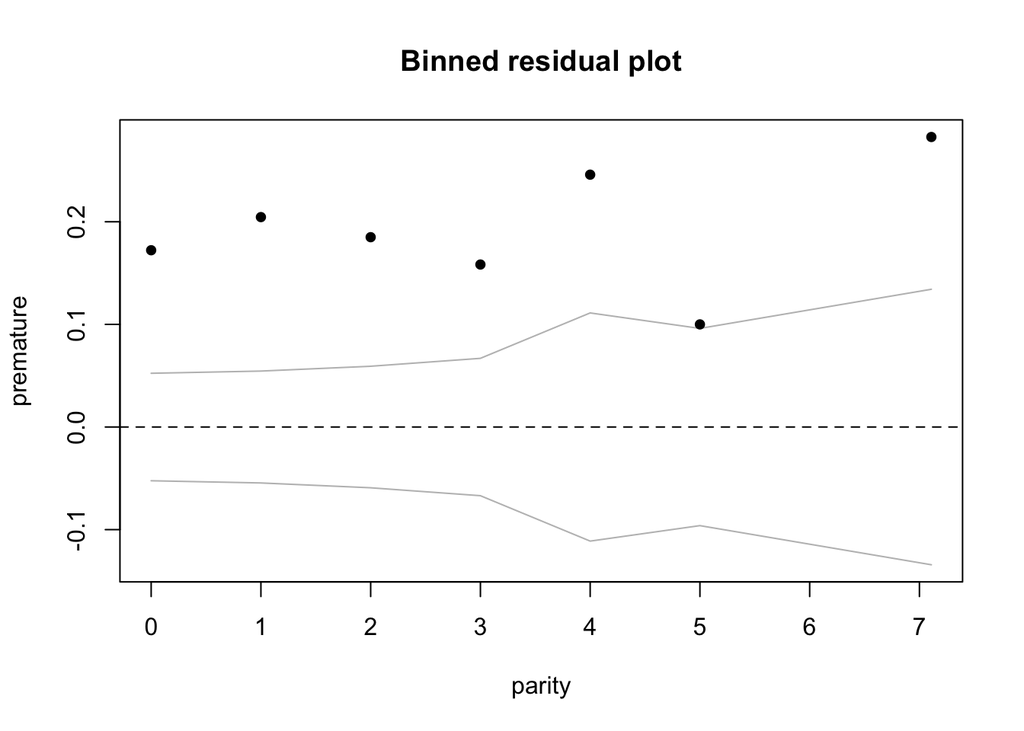

```r
binnedplot(maternal_data$parity, y=maternal_data$premature, xlab = "parity", ylab = "premature")
```

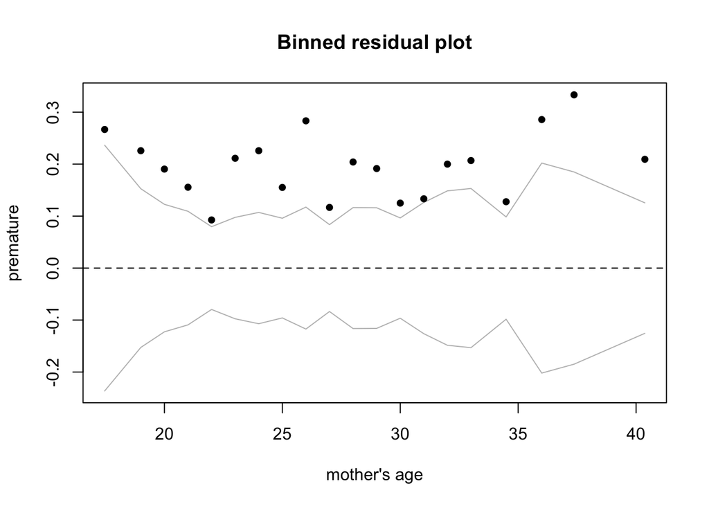

```r
binnedplot(maternal_data$mage, y=maternal_data$premature, xlab = "mother's age", ylab = "premature")
```

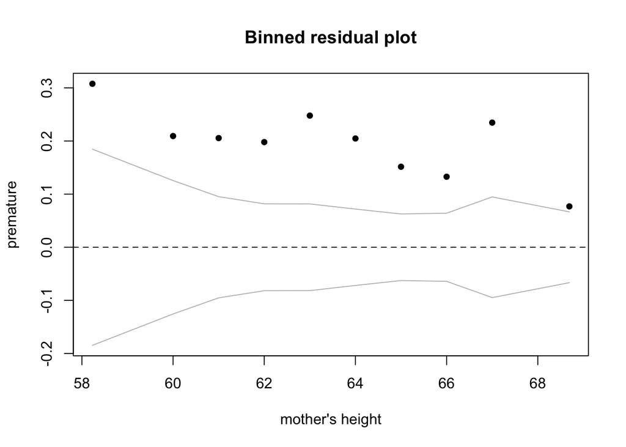

```r
binnedplot(maternal_data$mht, y=maternal_data$premature, xlab = "mother's height", ylab = "premature")
```

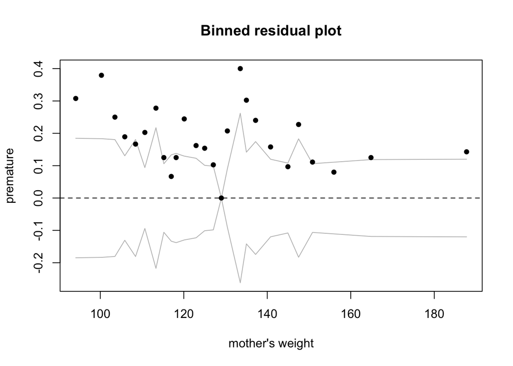

```r
binnedplot(maternal_data$mpregwt, y=maternal_data$premature, xlab = "mother's weight", ylab = "premature")
```

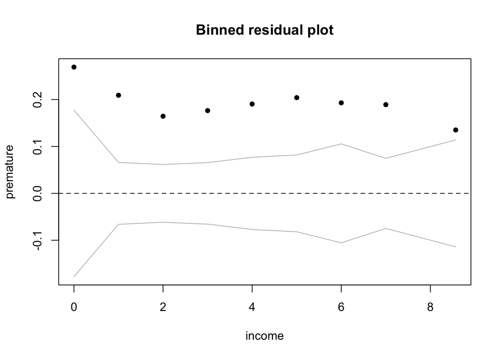

```r
binnedplot(maternal_data$inc, y=maternal_data$premature, xlab = "income", ylab = "premature")
```

Then try a logistic regression that has a main effect for every variable and linear predictors. Begin by centering the continuous predictors:

```r
maternal_data$parity.c <- maternal_data$parity - mean(maternal_data$parity)
maternal_data$mage.c <- maternal_data$mage - mean(maternal_data$mage)
maternal_data$mht.c <- maternal_data$mht - mean(maternal_data$mht)
maternal_data$mpregwt.c <- maternal_data$mpregwt - mean(maternal_data$mpregwt)
maternal_data$inc.c <- maternal_data$inc - mean(maternal_data$inc)

logis_mat_1 <- glm(premature~parity.c + mage.c + mht.c + mpregwt.c + inc.c + who_smoke + as.factor(mrace_new) + as.factor(med), data = maternal_data, family = binomial)
summary(logis_mat_1)
```

```
##
## Call:
## glm(formula = premature ~ parity.c + mage.c + mht.c + mpregwt.c +
##     inc.c + who_smoke + as.factor(mrace_new) + as.factor(med),
##     family = binomial, data = maternal_data)
##
## Deviance Residuals:
##     Min       1Q   Median       3Q      Max
## -1.7422  -0.6743  -0.5574  -0.4066   2.4474
##
## Coefficients:
##                        Estimate Std. Error z value Pr(>|z|)
## (Intercept)           -1.015552   0.963012  -1.055 0.291627
## parity.c              -0.018855   0.059855  -0.315 0.752748
## mage.c                 0.014886   0.020536   0.725 0.468528
## mht.c                 -0.026938   0.042223  -0.638 0.523481
## mpregwt.c             -0.011236   0.005525  -2.034 0.041985 *
## inc.c                  0.018709   0.043008   0.435 0.663559
## who_smoke              0.298560   0.185141   1.613 0.106829
## as.factor(mrace_new)6  0.131123   0.524208   0.250 0.802482
## as.factor(mrace_new)7  0.777520   0.232554   3.343 0.000828 ***
## as.factor(mrace_new)8  0.829257   0.414786   1.999 0.045582 *
## as.factor(mrace_new)9 -0.764453   1.054252  -0.725 0.468382
## as.factor(med)1       -0.356227   0.975016  -0.365 0.714846
## as.factor(med)2       -0.755554   0.962676  -0.785 0.432543
## as.factor(med)3       -0.621912   1.009737  -0.616 0.537951
## as.factor(med)4       -1.398608   0.979473  -1.428 0.153315
## as.factor(med)5       -0.971331   0.980907  -0.990 0.322058
## as.factor(med)7        1.953419   1.492183   1.309 0.190500
## ---
## Signif. codes:  0 '***' 0.001 '**' 0.01 '*' 0.05 '.' 0.1 ' ' 1
##
## (Dispersion parameter for binomial family taken to be 1)
##
##     Null deviance: 841.83  on 868  degrees of freedom
## Residual deviance: 794.50  on 852  degrees of freedom
## AIC: 828.5
##
## Number of Fisher Scoring iterations: 5
```

### model diagnostics

We first do binned residual plots for numeric variables: We don’t find any noticeable patterns.

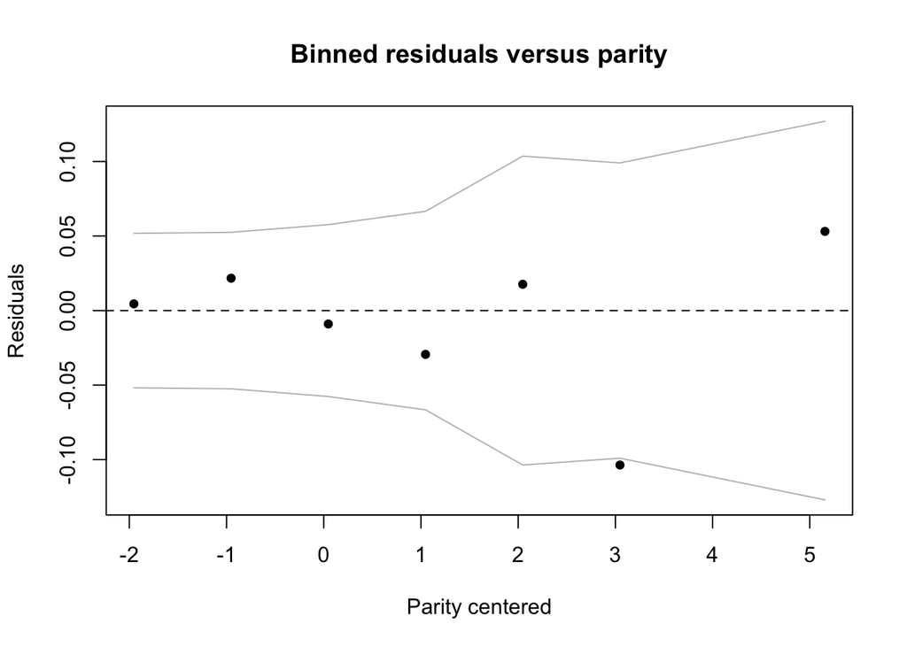

```r
rawresid1 = maternal_data$premature - fitted(logis_mat_1)
binnedplot(x=maternal_data$parity.c, y = rawresid1, xlab = "Parity centered", ylab = "Residuals",
main = "Binned residuals versus parity")
```

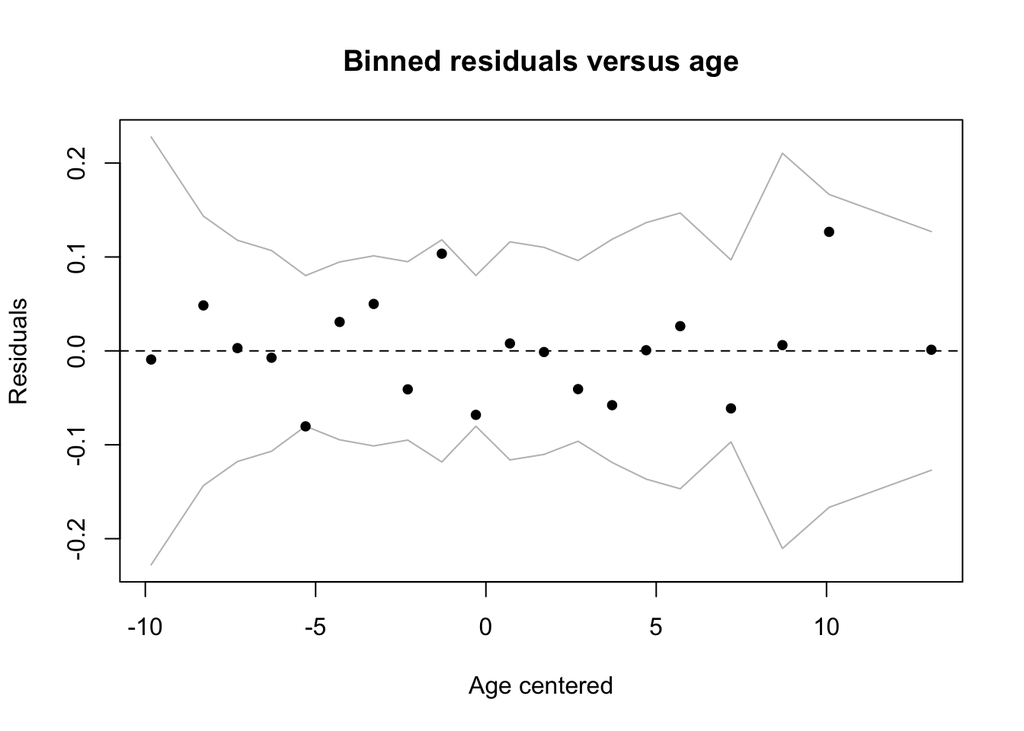

```r
binnedplot(x=maternal_data$mage.c, y = rawresid1, xlab = "Age centered", ylab = "Residuals",
main = "Binned residuals versus age")
```

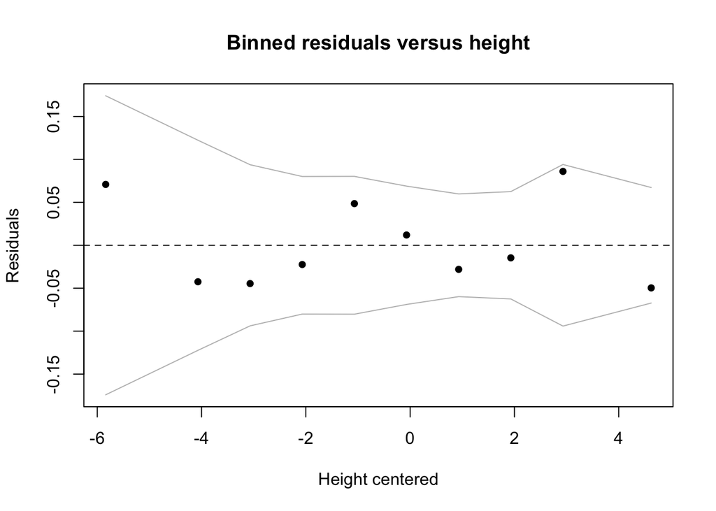

```r
binnedplot(x=maternal_data$mht.c, y = rawresid1, xlab = "Height centered", ylab = "Residuals",
main = "Binned residuals versus height")
```

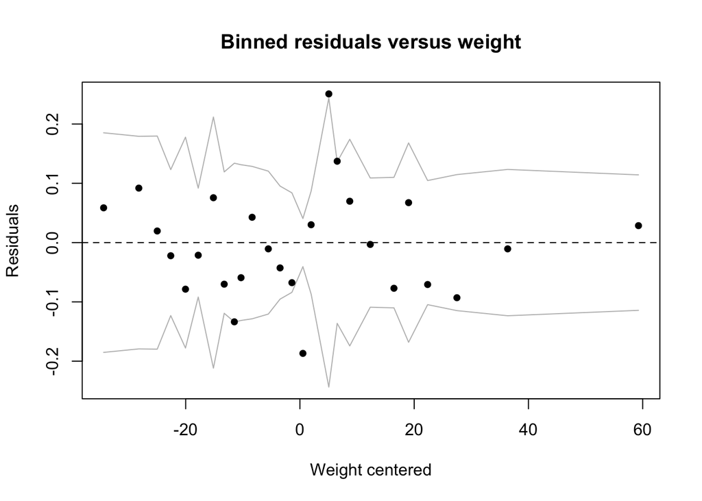

```r
binnedplot(x=maternal_data$mpregwt.c, y = rawresid1, xlab = "Weight centered", ylab = "Residuals",
main = "Binned residuals versus weight")
```

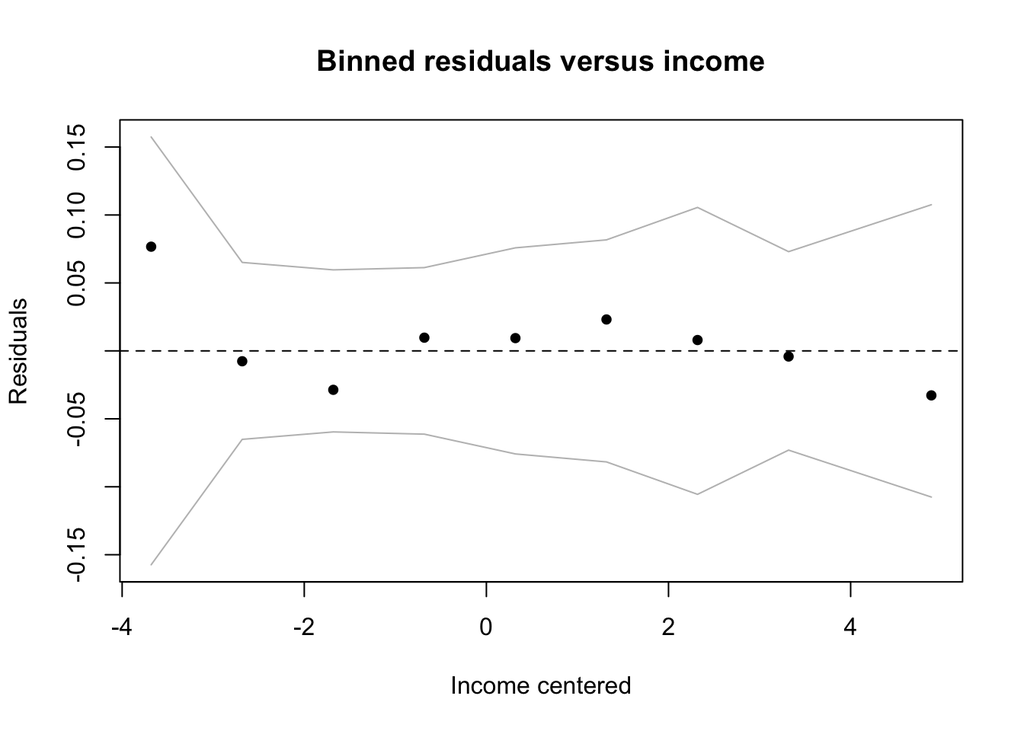

```r
binnedplot(x=maternal_data$inc.c, y = rawresid1, xlab = "Income centered", ylab = "Residuals",
main = "Binned residuals versus income")
```

Then look at average residuals by dummy variables using the tapply command: Nothing specific, except med level 7, which has few data, so we ignore that.

```r
tapply(rawresid1, maternal_data$who_smoke, mean)
```

```
##             0             1
## -1.845932e-13 -6.418171e-14
```

```r
tapply(rawresid1, maternal_data$mrace_new, mean)
```

```
##             5             6             7             8             9
##  1.325336e-17  6.533858e-16 -2.685290e-16 -1.649327e-16 -7.457275e-12
```

```r
tapply(rawresid1, maternal_data$med, mean)
```

```
##             0             1             2             3             4
##  4.585221e-15 -1.682536e-13 -1.276143e-13 -1.629276e-13 -2.040208e-13
##             5             7
##  1.926044e-17 -8.326673e-17
```

Then do the confusion matrix with .3 threshold and .4 threshold, nothing specific:

```r
threshold = 0.3
table(maternal_data$premature, logis_mat_1$fitted > threshold)
```

```
##
##     FALSE TRUE
##   0   638   67
##   1   125   39
```

```r
threshold = 0.4
table(maternal_data$premature, logis_mat_1$fitted > threshold)
```

```
##
##     FALSE TRUE
##   0   689   16
##   1   153   11
```

Then look at ROC curve: We didn’t find specific pattern from the model diagnostics, so we decide not to do transformations. We got area under the curve value: 0.6621.

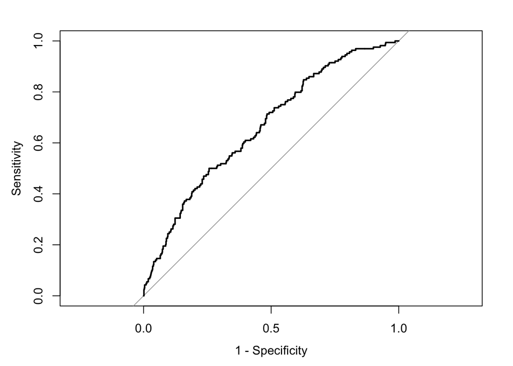

```
##
## Call:
## roc.default(response = maternal_data$premature, predictor = fitted(logis_mat_1),     plot = T, legacy.axes = T)
##
## Data: fitted(logis_mat_1) in 705 controls (maternal_data$premature 0) < 164 cases (maternal_data$premature 1).
## Area under the curve: 0.6621
```

```r
roc(maternal_data$premature, fitted(logis_mat_1), plot=T, legacy.axes=T)
```

Then we look at if there are interactions between variables: For question 2, we need to first check if there is interaction between smoking and mother’s race. We try the model with the interaction:

```r
logis_mat_2 <- glm(premature~parity.c + mage.c + mht.c + mpregwt.c + inc.c + who_smoke * as.factor(mrace_new) + as.factor(med), data = maternal_data, family = binomial)
summary(logis_mat_2)
```

```
##
## Call:
## glm(formula = premature ~ parity.c + mage.c + mht.c + mpregwt.c +
##     inc.c + who_smoke * as.factor(mrace_new) + as.factor(med),
##     family = binomial, data = maternal_data)
##
## Deviance Residuals:
##     Min       1Q   Median       3Q      Max
## -1.7570  -0.6802  -0.5512  -0.3958   2.4899
##
## Coefficients:
##                                   Estimate Std. Error z value Pr(>|z|)
## (Intercept)                      -1.064396   0.981566  -1.084 0.278194
## parity.c                         -0.028393   0.060385  -0.470 0.638209
## mage.c                            0.015910   0.020652   0.770 0.441081
## mht.c                            -0.032685   0.042785  -0.764 0.444903
## mpregwt.c                        -0.011428   0.005489  -2.082 0.037353 *
## inc.c                             0.021160   0.043054   0.491 0.623094
## who_smoke                         0.417801   0.229134   1.823 0.068243 .
## as.factor(mrace_new)6             0.181878   0.630329   0.289 0.772930
## as.factor(mrace_new)7             1.086085   0.315813   3.439 0.000584 ***
## as.factor(mrace_new)8             0.740483   0.500649   1.479 0.139128
## as.factor(mrace_new)9           -13.533701 412.570072  -0.033 0.973831
## as.factor(med)1                  -0.367430   0.992500  -0.370 0.711229
## as.factor(med)2                  -0.782404   0.983973  -0.795 0.426528
## as.factor(med)3                  -0.667123   1.032635  -0.646 0.518254
## as.factor(med)4                  -1.429465   0.998650  -1.431 0.152316
## as.factor(med)5                  -0.981000   1.000036  -0.981 0.326610
## as.factor(med)7                   1.961329   1.515627   1.294 0.195641
## who_smoke:as.factor(mrace_new)6  -0.092326   1.127852  -0.082 0.934758
## who_smoke:as.factor(mrace_new)7  -0.601374   0.427002  -1.408 0.159023
## who_smoke:as.factor(mrace_new)8   0.323221   0.847853   0.381 0.703038
## who_smoke:as.factor(mrace_new)9  14.513284 412.572014   0.035 0.971938
## ---
## Signif. codes:  0 '***' 0.001 '**' 0.01 '*' 0.05 '.' 0.1 ' ' 1
##
## (Dispersion parameter for binomial family taken to be 1)
##
##     Null deviance: 841.83  on 868  degrees of freedom
## Residual deviance: 789.01  on 848  degrees of freedom
## AIC: 831.01
##
## Number of Fisher Scoring iterations: 14
```

We do change in deviance test to see if the interaction is useful. We get a p value of 0.2408, so we don’t find interaction between smoking and race variable.

```r
anova(logis_mat_1, logis_mat_2, test= "Chisq")
```

|  | Resid. Df | Resid. Dev | Df | Deviance | Pr(>Chi) |
| --- | --- | --- | --- | --- | --- |
| 1 | 852 | 794.4989 | NA | NA | NA |
| 2 | 848 | 789.0106 | 4 | 5.488333 | 0.2407569 |

```r
logis_mat_3 <- glm(premature~parity.c + mage.c + mht.c + mpregwt.c + inc.c * as.factor(med) + who_smoke + as.factor(mrace_new), data = maternal_data, family = binomial)
summary(logis_mat_3)
```

```
##
## Call:
## glm(formula = premature ~ parity.c + mage.c + mht.c + mpregwt.c +
##     inc.c * as.factor(med) + who_smoke + as.factor(mrace_new),
##     family = binomial, data = maternal_data)
##
## Deviance Residuals:
##     Min       1Q   Median       3Q      Max
## -1.3101  -0.6588  -0.5474  -0.4083   2.4884
##
## Coefficients:
##                         Estimate Std. Error z value Pr(>|z|)
## (Intercept)            3.273e+01  1.146e+03   0.029  0.97722
## parity.c              -3.154e-02  6.190e-02  -0.509  0.61041
## mage.c                 2.156e-02  2.098e-02   1.028  0.30415
## mht.c                 -9.101e-03  4.343e-02  -0.210  0.83402
## mpregwt.c             -1.237e-02  5.618e-03  -2.202  0.02764 *
## inc.c                  2.850e+01  8.879e+02   0.032  0.97439
## as.factor(med)1       -3.429e+01  1.146e+03  -0.030  0.97613
## as.factor(med)2       -3.448e+01  1.146e+03  -0.030  0.97600
## as.factor(med)3       -3.453e+01  1.146e+03  -0.030  0.97597
## as.factor(med)4       -3.514e+01  1.146e+03  -0.031  0.97554
## as.factor(med)5       -3.477e+01  1.146e+03  -0.030  0.97580
## as.factor(med)7        8.345e+00  3.283e+03   0.003  0.99797
## who_smoke              2.836e-01  1.870e-01   1.516  0.12942
## as.factor(mrace_new)6 -2.403e-02  5.479e-01  -0.044  0.96501
## as.factor(mrace_new)7  7.511e-01  2.375e-01   3.162  0.00157 **
## as.factor(mrace_new)8  8.020e-01  4.183e-01   1.917  0.05524 .
## as.factor(mrace_new)9 -7.979e-01  1.057e+00  -0.755  0.45033
## inc.c:as.factor(med)1 -2.868e+01  8.879e+02  -0.032  0.97423
## inc.c:as.factor(med)2 -2.853e+01  8.879e+02  -0.032  0.97437
## inc.c:as.factor(med)3 -2.829e+01  8.879e+02  -0.032  0.97458
## inc.c:as.factor(med)4 -2.842e+01  8.879e+02  -0.032  0.97446
## inc.c:as.factor(med)5 -2.845e+01  8.879e+02  -0.032  0.97444
## inc.c:as.factor(med)7 -1.310e+01  1.451e+03  -0.009  0.99279
## ---
## Signif. codes:  0 '***' 0.001 '**' 0.01 '*' 0.05 '.' 0.1 ' ' 1
##
## (Dispersion parameter for binomial family taken to be 1)
##
##     Null deviance: 841.83  on 868  degrees of freedom
## Residual deviance: 781.84  on 846  degrees of freedom
## AIC: 827.84
##
## Number of Fisher Scoring iterations: 15
```

We do change in deviance test to see if the interaction is useful. We get a p value of 0.048, so we might find interaction between income and education.

```r
anova(logis_mat_1, logis_mat_3, test= "Chisq")
```

|  | Resid. Df | Resid. Dev | Df | Deviance | Pr(>Chi) |
| --- | --- | --- | --- | --- | --- |
| 1 | 852 | 794.4989 | NA | NA | NA |
| 2 | 846 | 781.8387 | 6 | 12.66021 | 0.04876068 |

We then check the ROC curve: We got a lightly better area under the curve value: 0.6729.

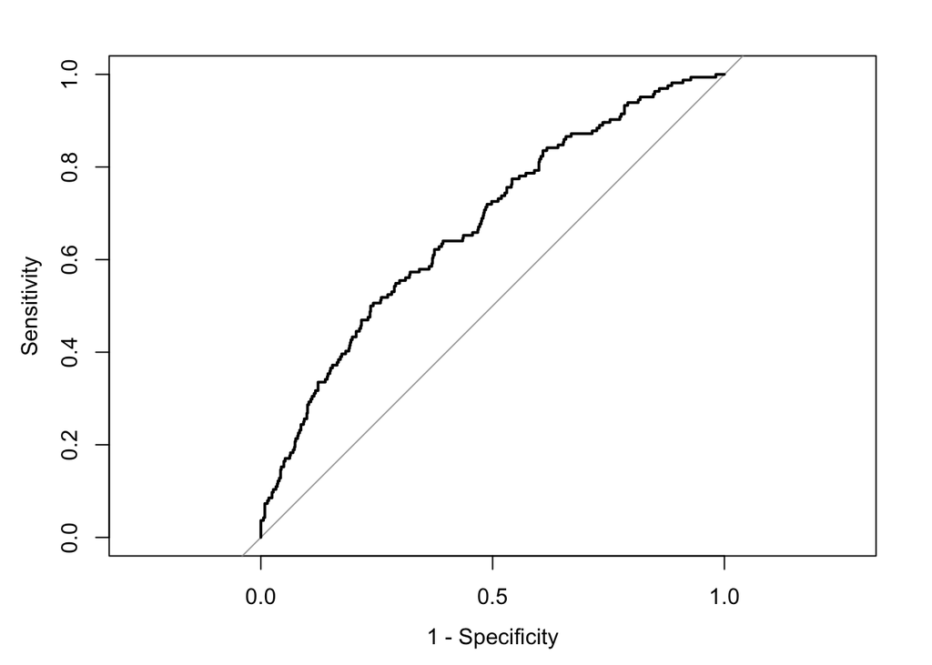

```
##
## Call:
## roc.default(response = maternal_data$premature, predictor = fitted(logis_mat_3),     plot = T, legacy.axes = T)
##
## Data: fitted(logis_mat_3) in 705 controls (maternal_data$premature 0) < 164 cases (maternal_data$premature 1).
## Area under the curve: 0.6729
```

```r
roc(maternal_data$premature, fitted(logis_mat_3), plot=T, legacy.axes=T)
```

```r
logis_mat_3 <- glm(premature~parity.c + mage.c + mht.c + mpregwt.c + inc.c * as.factor(med) + who_smoke + as.factor(mrace_new), data = maternal_data, family = binomial)
summary(logis_mat_3)
```

```
##
## Call:
## glm(formula = premature ~ parity.c + mage.c + mht.c + mpregwt.c +
##     inc.c * as.factor(med) + who_smoke + as.factor(mrace_new),
##     family = binomial, data = maternal_data)
##
## Deviance Residuals:
##     Min       1Q   Median       3Q      Max
## -1.3101  -0.6588  -0.5474  -0.4083   2.4884
##
## Coefficients:
##                         Estimate Std. Error z value Pr(>|z|)
## (Intercept)            3.273e+01  1.146e+03   0.029  0.97722
## parity.c              -3.154e-02  6.190e-02  -0.509  0.61041
## mage.c                 2.156e-02  2.098e-02   1.028  0.30415
## mht.c                 -9.101e-03  4.343e-02  -0.210  0.83402
## mpregwt.c             -1.237e-02  5.618e-03  -2.202  0.02764 *
## inc.c                  2.850e+01  8.879e+02   0.032  0.97439
## as.factor(med)1       -3.429e+01  1.146e+03  -0.030  0.97613
## as.factor(med)2       -3.448e+01  1.146e+03  -0.030  0.97600
## as.factor(med)3       -3.453e+01  1.146e+03  -0.030  0.97597
## as.factor(med)4       -3.514e+01  1.146e+03  -0.031  0.97554
## as.factor(med)5       -3.477e+01  1.146e+03  -0.030  0.97580
## as.factor(med)7        8.345e+00  3.283e+03   0.003  0.99797
## who_smoke              2.836e-01  1.870e-01   1.516  0.12942
## as.factor(mrace_new)6 -2.403e-02  5.479e-01  -0.044  0.96501
## as.factor(mrace_new)7  7.511e-01  2.375e-01   3.162  0.00157 **
## as.factor(mrace_new)8  8.020e-01  4.183e-01   1.917  0.05524 .
## as.factor(mrace_new)9 -7.979e-01  1.057e+00  -0.755  0.45033
## inc.c:as.factor(med)1 -2.868e+01  8.879e+02  -0.032  0.97423
## inc.c:as.factor(med)2 -2.853e+01  8.879e+02  -0.032  0.97437
## inc.c:as.factor(med)3 -2.829e+01  8.879e+02  -0.032  0.97458
## inc.c:as.factor(med)4 -2.842e+01  8.879e+02  -0.032  0.97446
## inc.c:as.factor(med)5 -2.845e+01  8.879e+02  -0.032  0.97444
## inc.c:as.factor(med)7 -1.310e+01  1.451e+03  -0.009  0.99279
## ---
## Signif. codes:  0 '***' 0.001 '**' 0.01 '*' 0.05 '.' 0.1 ' ' 1
##
## (Dispersion parameter for binomial family taken to be 1)
##
##     Null deviance: 841.83  on 868  degrees of freedom
## Residual deviance: 781.84  on 846  degrees of freedom
## AIC: 827.84
##
## Number of Fisher Scoring iterations: 15
```

And we take exponential for the coefficients and confidence intervals to get the odds:

```r
exp(logis_mat_3$coefficients)
```

```
##           (Intercept)              parity.c                mage.c
##          1.642861e+14          9.689557e-01          1.021791e+00
##                 mht.c             mpregwt.c                 inc.c
##          9.909404e-01          9.877046e-01          2.392367e+12
##       as.factor(med)1       as.factor(med)2       as.factor(med)3
##          1.282398e-15          1.061449e-15          1.012166e-15
##       as.factor(med)4       as.factor(med)5       as.factor(med)7
##          5.485082e-16          7.951732e-16          4.209359e+03
##             who_smoke as.factor(mrace_new)6 as.factor(mrace_new)7
##          1.327880e+00          9.762533e-01          2.119283e+00
## as.factor(mrace_new)8 as.factor(mrace_new)9 inc.c:as.factor(med)1
##          2.229899e+00          4.502620e-01          3.510118e-13
## inc.c:as.factor(med)2 inc.c:as.factor(med)3 inc.c:as.factor(med)4
##          4.085311e-13          5.152748e-13          4.535009e-13
## inc.c:as.factor(med)5 inc.c:as.factor(med)7
##          4.418542e-13          2.043168e-06
```

```r
exp(confint(logis_mat_3))
```

```
##                               2.5 %        97.5 %
## (Intercept)           5.877729e+215  7.092113e+55
## parity.c               8.569334e-01  1.092963e+00
## mage.c                 9.800725e-01  1.064270e+00
## mht.c                  9.103694e-01  1.079630e+00
## mpregwt.c              9.765752e-01  9.983459e-01
## inc.c                 1.836551e+212 3.803876e+174
## as.factor(med)1        1.654980e-89 1.610502e-197
## as.factor(med)2        1.564532e-45 1.969778e-196
## as.factor(med)3        1.551941e-86 6.347622e-119
## as.factor(med)4        1.851500e-43 2.676122e-197
## as.factor(med)5        3.207468e-90 3.272757e-201
## as.factor(med)7        2.486090e-08  4.928507e+14
## who_smoke              9.206806e-01  1.918340e+00
## as.factor(mrace_new)6  2.978351e-01  2.659879e+00
## as.factor(mrace_new)7  1.325023e+00  3.368739e+00
## as.factor(mrace_new)8  9.545518e-01  4.984606e+00
## as.factor(mrace_new)9  2.432247e-02  2.391258e+00
## inc.c:as.factor(med)1 2.986412e-172 9.083281e-152
## inc.c:as.factor(med)2 5.385344e-176 2.762417e-226
## inc.c:as.factor(med)3 5.640739e-170 2.634480e-110
## inc.c:as.factor(med)4 1.092729e-168  4.458507e-84
## inc.c:as.factor(med)5 4.392904e-203 1.078450e-259
## inc.c:as.factor(med)7  1.628644e-11  1.533865e-01
```

### Interpretation:

Answer for question 1:

Holding other variables constant, mothers who smoke tend to have 32.79% higher odds of having pre-term birth than mothers who do not smoke. The 95% confidence interval for the odds of pre-term birth for smokering mothers are from 7.93% lower to 91.83% higher (92.07%, 191.83%) than non-smoking mothers.

Answer for question 2:

We did change in deviance test to see if the interaction between smoking and race is valid. We got a p value of 0.2408 > 0.05, so we don’t find interaction between smoking and race variable.

Answer for question 3:

I found several interesting associations with the odds of pre-term birth: 1, We found it interesting that holding other variables constant, when pre-pregnancy weight increase by 1 pound, the odds of getting a pre-term birth in fact reduce by 1.23%, with a confidence interval of (0.17%, 2.34%) reducing odds of having pre-term birth.

2, We found another thing that holding other variables constant, mothers of race level 7 and 8, which is black and asian, in fact have way much higher odds of pre-term birth than white mothers. Black mothers tend to have 111.93% higher odds (more than 2 times of the odds) of having a pre-term birth than white mothers; asian mothers tend to have 122.99% higher odds (more than 2 times of the odds) of having a pre-term birth than white mothers.